# Analysis Report on the WeRateDogs Twitter Using Twitters API

The datasets involved in this analysis are:

- The WeRateDogs Twitter archive dataset
- The Image prediction dataset
- The Tweet likes and retweet dataset

I wrangled this datasets by:

- **Gathering**: which involved downloading Manually, downloading programmatically using Requests library and using the Twitter API.
- **Accessing**: which involved both Visual accessment and programmatic accessment to find the Quality and tidiness issues.
- **Cleaning**: which involved rectifying the issues discovered during the Accessment phase.
- **Storing**: hich involved storing the cleaned dataset as twitter-master-archive.csv.

When I was done with storing the cleaned dataset I went ahead to analysis it so as to get insights from the data set and I had the following findings:

### Insight

- The most retweeted tweet was of a Labrador retriever
- The top rated dog was a Labrador retriever
- The most popular dog type that was tweeted was the golden retriever
- Tweet with the highest number of likes
- Tweet with the lowest number of likes

### Visuals

- The most retweeted dog state
- The most popular dog names

### The most retweeted tweet was of a Labrador retriever

[figure not shown]

This is the image of the og that had the highest number of retweet, this dog also happened to have the highest number of likes

### The top rated dog was a Labrador retriever

[figure not shown]

This is the picture of the tweet with the highest number of rating, which is a very high number of 165 but the reason for the very high rating is because of the number of dogs in the post

### The most popular dog type that was tweeted was the golden retriever

In this particular query, I counted the different dog type so as to get the dog type that as most popular in the dataset. After the query, I was able to get the most popular dog type as a golden retriever.

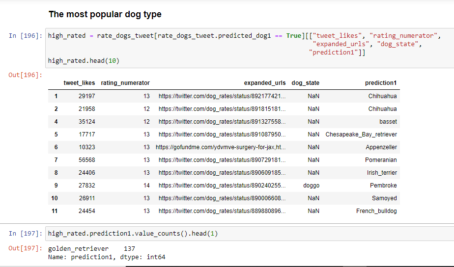

### Tweet with the lowest number of likes

[figure not shown]

The Tweet in the picture above had the lowest number of likes.

### The most retweeted dog state

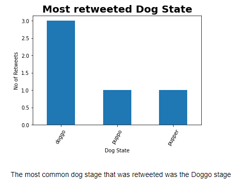

### The most popular dog names

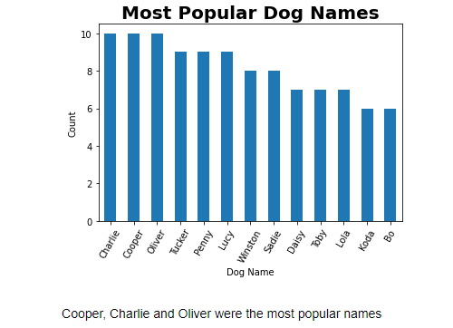